# lab5

Adam VanGorp and Mitchell Kazin

11/4/2019

Github Repository: https://github.com/Cygorp/ds202_lab5  
Owners Username: Cygorp  
Partners Username: mitchellkazin15

## 1.

```r
diabetes<-read.table('diabetes.txt',header=TRUE)
head(diabetes)
```

```
##     id chol stab.glu hdl ratio glyhb   location age gender height weight
## 1 1000  203       82  56   3.6  4.31 Buckingham  46 female     62    121
## 2 1001  165       97  24   6.9  4.44 Buckingham  29 female     64    218
## 3 1002  228       92  37   6.2  4.64 Buckingham  58 female     61    256
## 4 1003   78       93  12   6.5  4.63 Buckingham  67   male     67    119
## 5 1005  249       90  28   8.9  7.72 Buckingham  64   male     68    183
## 6 1008  248       94  69   3.6  4.81 Buckingham  34   male     71    190
##    frame bp.1s bp.1d bp.2s bp.2d waist hip time.ppn
## 1 medium   118    59    NA    NA    29  38      720
## 2  large   112    68    NA    NA    46  48      360
## 3  large   190    92   185    92    49  57      180
## 4  large   110    50    NA    NA    33  38      480
## 5 medium   138    80    NA    NA    44  41      300
## 6  large   132    86    NA    NA    36  42      195
```

## 2.

```r
library(tidyverse)
diabetes[diabetes == ''] = NA
droplevels(diabetes)
```

```r
head(diabetes)
```

```
##     id chol stab.glu hdl ratio glyhb   location age gender height weight
## 1 1000  203       82  56   3.6  4.31 Buckingham  46 female     62    121
## 2 1001  165       97  24   6.9  4.44 Buckingham  29 female     64    218
## 3 1002  228       92  37   6.2  4.64 Buckingham  58 female     61    256
## 4 1003   78       93  12   6.5  4.63 Buckingham  67   male     67    119
## 5 1005  249       90  28   8.9  7.72 Buckingham  64   male     68    183
## 6 1008  248       94  69   3.6  4.81 Buckingham  34   male     71    190
##    frame bp.1s bp.1d bp.2s bp.2d waist hip time.ppn
## 1 medium   118    59    NA    NA    29  38      720
## 2  large   112    68    NA    NA    46  48      360
## 3  large   190    92   185    92    49  57      180
## 4  large   110    50    NA    NA    33  38      480
## 5 medium   138    80    NA    NA    44  41      300
## 6  large   132    86    NA    NA    36  42      195
```

```r
str(diabetes)
```

```
## 'data.frame':    403 obs. of  19 variables:
##  $ id      : int  1000 1001 1002 1003 1005 1008 1011 1015 1016 1022 ...
##  $ chol    : int  203 165 228 78 249 248 195 227 177 263 ...
##  $ stab.glu: int  82 97 92 93 90 94 92 75 87 89 ...
##  $ hdl     : int  56 24 37 12 28 69 41 44 49 40 ...
##  $ ratio   : num  3.6 6.9 6.2 6.5 8.9 ...
##  $ glyhb   : num  4.31 4.44 4.64 4.63 7.72 ...
##  $ location: Factor w/ 2 levels "Buckingham","Louisa": 1 1 1 1 1 1 1 1 1 1 ...
##  $ age     : int  46 29 58 67 64 34 30 37 45 55 ...
##  $ gender  : Factor w/ 2 levels "female","male": 1 1 1 2 2 2 2 2 2 1 ...
##  $ height  : int  62 64 61 67 68 71 69 59 69 63 ...
##  $ weight  : int  121 218 256 119 183 190 191 170 166 202 ...
##  $ frame   : Factor w/ 4 levels "","large","medium",..: 3 2 2 2 3 2 3 3 2 4 ...
##  $ bp.1s   : int  118 112 190 110 138 132 161 NA 160 108 ...
##  $ bp.1d   : int  59 68 92 50 80 86 112 NA 80 72 ...
##  $ bp.2s   : int  NA NA 185 NA NA NA 161 NA 128 NA ...
##  $ bp.2d   : int  NA NA 92 NA NA NA 112 NA 86 NA ...
##  $ waist   : int  29 46 49 33 44 36 46 34 34 45 ...
##  $ hip     : int  38 48 57 38 41 42 49 39 40 50 ...
##  $ time.ppn: int  720 360 180 480 300 195 720 1020 300 240 ...
```

## 3.

```r
diabetes_reduced <- select(diabetes, -c(id, bp.2s, bp.2d))
```

## 4.

```r
index.na1=which(apply(is.na(diabetes_reduced), 1, any) == TRUE)
diabetes_clean <- diabetes_reduced[-index.na1,]
nrow(diabetes_clean)
```

```
## [1] 366
```

## 5.

```r
index.na2=which(apply(is.na(diabetes_clean), 1, any) == TRUE)
index.na2
```

```
## named integer(0)
```

To see if all rows that have missing values were dropped we just have to run the given line of code again. If there are no results then there are no missing values.

## 6.

Taking the log value of glyhb would make the data less right-skewed and more symmetric. A potential downside is information about the drastic differences between some peoples glyhb values.

## 7.

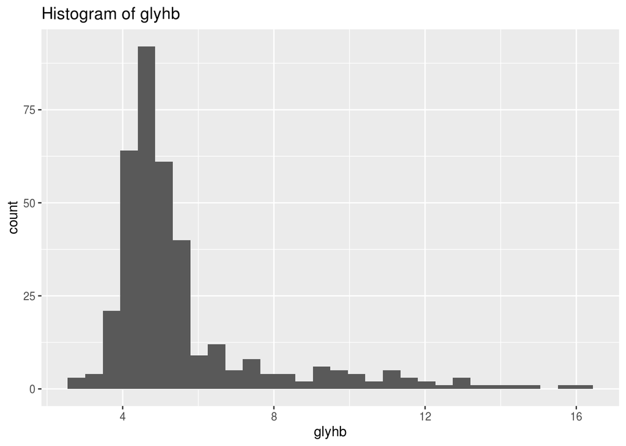

```r
ggplot(diabetes_clean, aes(glyhb)) + geom_histogram() + ggtitle("Histogram of glyhb")
```

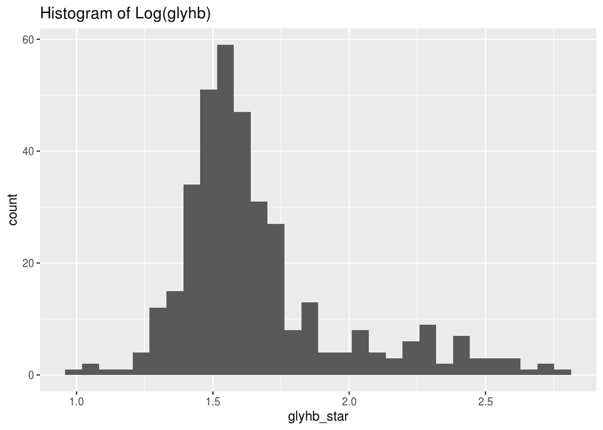

```r
diabetes_clean$glyhb_star = log(diabetes_clean$glyhb)
ggplot(diabetes_clean, aes(glyhb_star)) + geom_histogram() + ggtitle("Histogram of Log(glyhb)")
```

## 8.

The larger the frame, the higher the glyhb_star mean. Buckingham has a slightly higher glyhb_star average than Louisa. Men are more likely to have a higher glyhb_star than women.

```r
diabetes_clean %>% group_by(frame) %>% summarise(mean.glyhb = mean(glyhb_star))
```

```
## # A tibble: 3 x 2
##   frame  mean.glyhb
##   <fct>       <dbl>
## 1 large        1.75
## 2 medium       1.67
## 3 small        1.58
```

```r
diabetes_clean %>% group_by(location) %>% summarise(mean.glyhb = mean(glyhb_star))
```

```
## # A tibble: 2 x 2
##   location   mean.glyhb
##   <fct>           <dbl>
## 1 Buckingham       1.69
## 2 Louisa           1.65
```

```r
diabetes_clean %>% group_by(gender) %>% summarise(mean.glyhb = mean(glyhb_star))
```

```
## # A tibble: 2 x 2
##   gender mean.glyhb
##   <fct>       <dbl>
## 1 female       1.65
## 2 male         1.69
```

## 10.

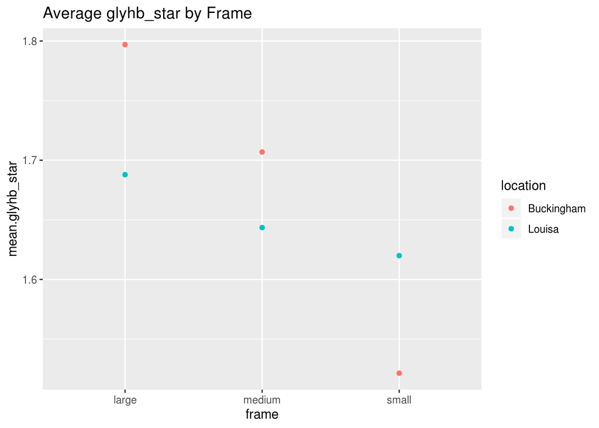

```r
 diabetes_clean %>% group_by(frame,location) %>% summarise (mean.glyhb_star= mean(glyhb_star)) %>% ggplot(aes(x = frame, y = mean.glyhb_star, color = location)) + geom_point() + ggtitle("Average glyhb_star by Frame")
```

## 11.

The only trend that is relatively clear from these graphs is that as ratio increases, glyhb_star will also increase.

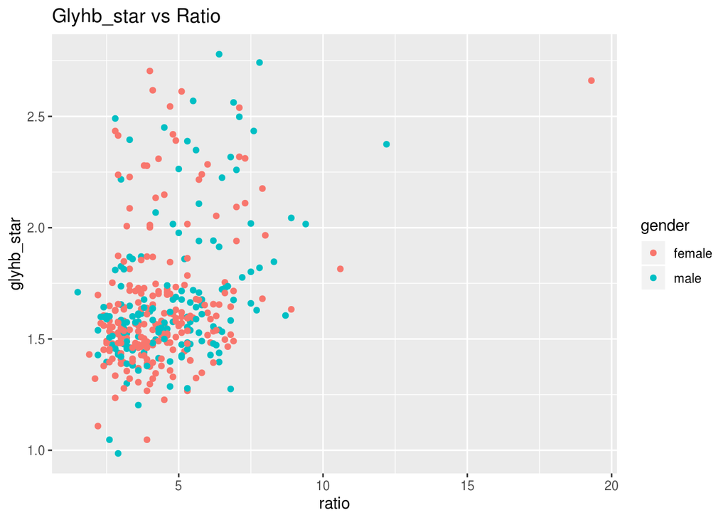

```r
ggplot(diabetes_clean, aes(ratio, glyhb_star, color = gender)) + geom_point() + ggtitle("Glyhb_star vs Ratio")
```

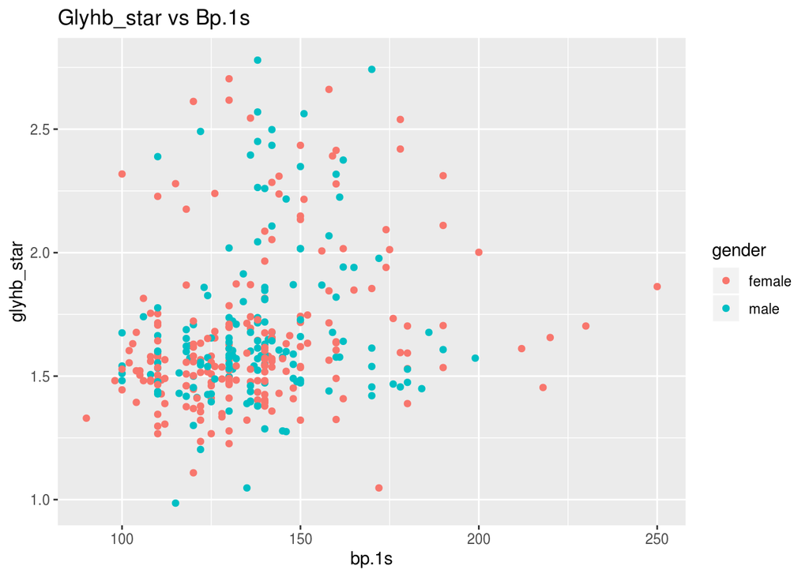

```r
ggplot(diabetes_clean, aes(bp.1s, glyhb_star, color = gender)) + geom_point() + ggtitle("Glyhb_star vs Bp.1s")
```

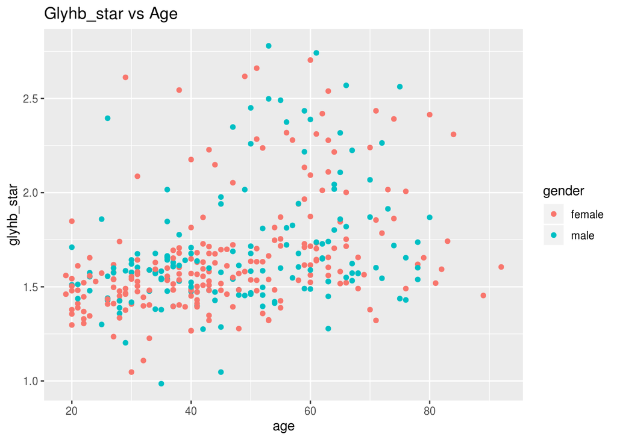

```r
ggplot(diabetes_clean, aes(age, glyhb_star, color = gender)) + geom_point() + ggtitle("Glyhb_star vs Age")
```

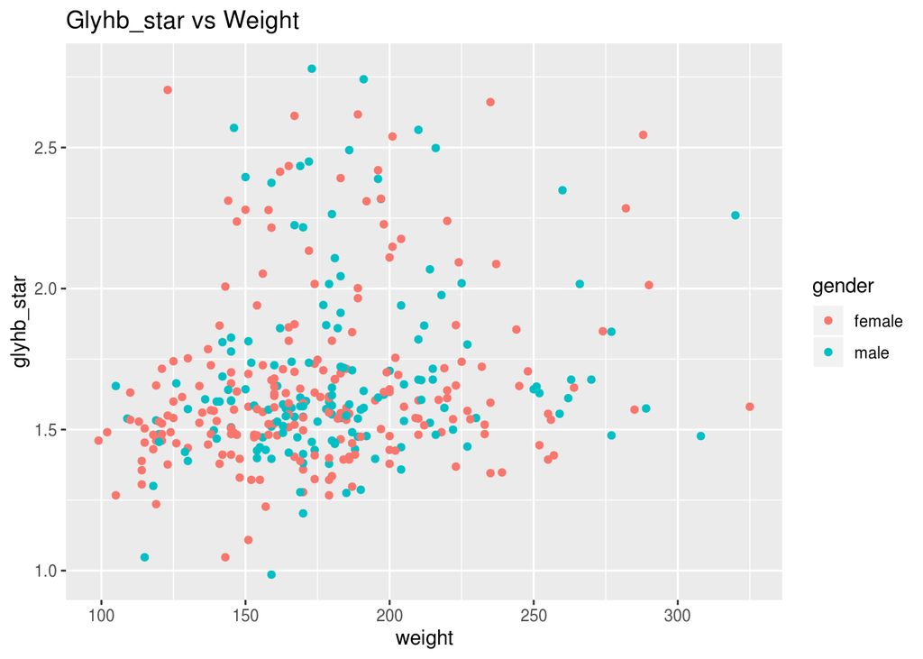

```r
ggplot(diabetes_clean, aes(weight, glyhb_star, color = gender)) + geom_point() + ggtitle("Glyhb_star vs Weight")
```

## 12.

In order to see patterns in the data better, it may be helpful to facet by gender as well. Another way to visualize the data is with bar graphs.

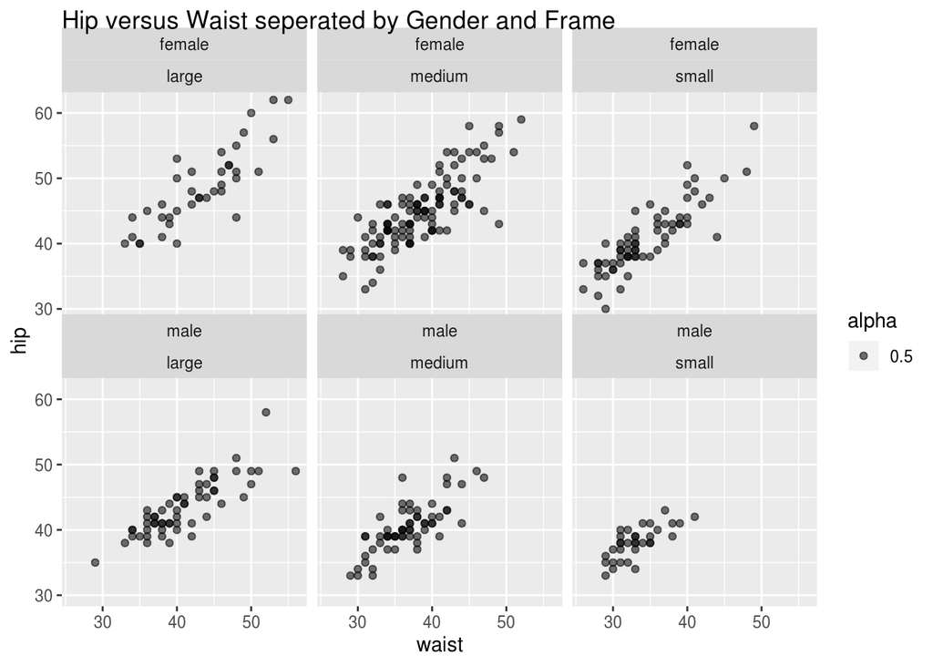

```r
ggplot(diabetes_clean,aes(y=hip,x=waist, alpha=.5)) + geom_point() + facet_wrap(gender~frame) + ggtitle("Hip versus Waist seperated by Gender and Frame")
```

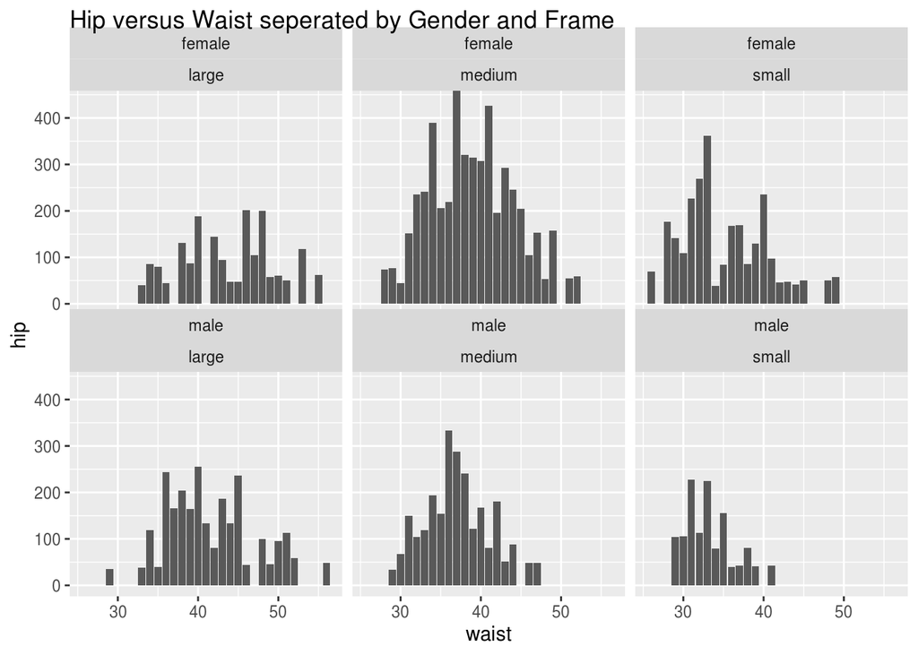

```r
ggplot(diabetes_clean,aes(y=hip,x=waist)) + geom_col() + facet_wrap(gender~frame) + ggtitle("Hip versus Waist seperated by Gender and Frame")
```

## 13.

The gather function takes data that is across multiple columns and condenses it into one column in the form of key value pairs. The spread function takes single column data and expands it over multiple columns based on the key value pairs of the first column.

## 14.

They are complementary function in the sense that you can gather the data and then spread it to get back the original data and vice versa.

## 15.

```r
fit = lm(glyhb_star ~stab.glu + age + waist + ratio+ factor(frame),data=diabetes_clean)
 summary(fit)
```

```
##
## Call:
## lm(formula = glyhb_star ~ stab.glu + age + waist + ratio + factor(frame),
##     data = diabetes_clean)
##
## Residuals:
##     Min      1Q  Median      3Q     Max
## -1.0548 -0.1176 -0.0123  0.1020  1.0613
##
## Coefficients:
##                      Estimate Std. Error t value Pr(>|t|)
## (Intercept)         0.8330897  0.0984743   8.460 6.86e-16 ***
## stab.glu            0.0035182  0.0002200  15.992  < 2e-16 ***
## age                 0.0033632  0.0007144   4.708 3.58e-06 ***
## waist               0.0047925  0.0022352   2.144  0.03270 *
## ratio               0.0219341  0.0068169   3.218  0.00141 **
## factor(frame)medium 0.0309167  0.0283657   1.090  0.27648
## factor(frame)small  0.0131840  0.0351518   0.375  0.70784
## ---
## Signif. codes:  0 '***' 0.001 '**' 0.01 '*' 0.05 '.' 0.1 ' ' 1
##
## Residual standard error: 0.2085 on 359 degrees of freedom
## Multiple R-squared:  0.5643, Adjusted R-squared:  0.557
## F-statistic: 77.49 on 6 and 359 DF,  p-value: < 2.2e-16
```

## 17.

The output below is the predicted value from our model.

```r
new_diabetes = data.frame(90, 35, 30, 5.1, 'small')
names(new_diabetes) = c("stab.glu", "age", "waist", "ratio", "frame")
predict(fit, new_diabetes)
```

```
##       1
## 1.53626
```

## 18.

Inference is when you are looking to infer the effect of how an output is generated as a function of the data. Whereas prediction is when you are trying to choose a correct identifier from a set of outcomes. Inference is looking at the effect of x on y and prediction wants to see how often x is right.

## 19.

A linear regression model is better than a knn regression model when trying to fit and estimate a small number of coefficients.A disadvantage of a linear regression compared to knn is that linear regressions make strong assumptions about the form of f(x). This means if the relationship isn’t linear the resulting model can be misleading/ wont fit well. A knn regression model doesn’t assume an explicit form of f(x).

## 20.

I believe that I had a solid grasp of what data science is from taking 201 before this class so my views on data science haven’t changed, but I do believe that my knowledge on and skills on the subject have grown.

The most suprising part about DS to us was how many diferrent ways there are to view and manipulate data. There isn’t always a “right” answer how to do things and methods vary from person to person.The most challenging part and the most enjoyable part of this course had to deal with collaborating on lab assingments and the group project. Working with others made the class more enjoyable but learning git and github to collaborate was challenging but rewarding.